# Child (under 5) Mortality rates and Leading causes of Death : A case study

##### We note the steady decline in mortality rates of children under the age of 5 in the past twenty-five years.

##### This is based on data collected from UNICEF and WHO.

##### Also the leading causes for death among children under the age of 5 is noted.

##### As a case study we consider the incidence of high mortality rates in children under 5 years for three leading causes : Malaria, Pneumonia and Diarrhoea .

#### The supporting graphs show the countries where under 5 mortality rates are the highest for these causes.

```python
from IPython.display import HTML
HTML('<iframe width="560" height="315" src="https://www.youtube.com/embed/hRrvsM4jxpQ" frameborder="0" allow="autoplay; encrypted-media" allowfullscreen></iframe>')
```

[video not shown]

```python
import sys
import types
import pandas as pd
from botocore.client import Config
import ibm_boto3

def __iter__(self): return 0

# @hidden_cell
# The following code accesses a file in your IBM Cloud Object Storage. It includes your credentials.
# You might want to remove those credentials before you share your notebook.
client_c4c30ecfa40c4cbb923cfad6f1dd1055 = ibm_boto3.client(service_name='s3',
    ibm_api_key_id='1zfEV_xrU4k4idl-64bA90PR_Fn6wOQvGOVO11OtAKdX',
    ibm_auth_endpoint="https://iam.ng.bluemix.net/oidc/token",
    config=Config(signature_version='oauth'),
    endpoint_url='https://s3-api.us-geo.objectstorage.service.networklayer.com')

body = client_c4c30ecfa40c4cbb923cfad6f1dd1055.get_object(Bucket='childmortalityrateunder5analysib0419166aaf146e5a4d747e61df6a5a9',Key='data.csv')['Body']
# add missing __iter__ method, so pandas accepts body as file-like object
if not hasattr(body, "__iter__"): body.__iter__ = types.MethodType( __iter__, body )

df_data_1 = pd.read_csv(body)
df_data_1.head()
```

|  | Year | Under 5 mortality rate | Infant mortality rate | Neonatal mortality rate |
| --- | --- | --- | --- | --- |
| 0 | 1990 | 93.4 | 64.8 | 36.8 |
| 1 | 1991 | 92.1 | 63.9 | 36.3 |
| 2 | 1992 | 90.9 | 63.1 | 35.9 |
| 3 | 1993 | 89.7 | 62.3 | 35.4 |
| 4 | 1994 | 88.7 | 61.4 | 34.9 |

# Under 5 mortality date 1990-2016

### The global under-five mortality rate declined by 56 per cent, from 93 deaths per 1,000 live births in 1990 to 41 per 1,000 in 2016. Despite substantial progress, improving child survival remains a matter of urgent concern.

### In 2016, an estimated 5.6 million children died before reaching their fifth birthday, mostly from preventable diseases. This translates to 15,000 under-five deaths per day, an intolerably high number of largely preventable child deaths.

```python
df_data_1
```

|  | Year | Under 5 mortality rate | Infant mortality rate | Neonatal mortality rate |
| --- | --- | --- | --- | --- |
| 0 | 1990 | 93.4 | 64.8 | 36.8 |
| 1 | 1991 | 92.1 | 63.9 | 36.3 |
| 2 | 1992 | 90.9 | 63.1 | 35.9 |
| 3 | 1993 | 89.7 | 62.3 | 35.4 |
| 4 | 1994 | 88.7 | 61.4 | 34.9 |
| 5 | 1995 | 87.3 | 60.5 | 34.4 |
| 6 | 1996 | 85.6 | 59.4 | 33.7 |
| 7 | 1997 | 84.0 | 58.2 | 33.1 |
| 8 | 1998 | 82.1 | 56.9 | 32.3 |
| 9 | 1999 | 79.9 | 55.4 | 31.5 |
| 10 | 2000 | 77.5 | 53.9 | 30.7 |
| 11 | 2001 | 74.8 | 52.1 | 29.8 |
| 12 | 2002 | 72.0 | 50.3 | 28.9 |
| 13 | 2003 | 69.2 | 48.6 | 28.0 |
| 14 | 2004 | 66.7 | 46.9 | 27.0 |
| 15 | 2005 | 63.7 | 45.1 | 26.1 |
| 16 | 2006 | 61.1 | 43.4 | 25.3 |
| 17 | 2007 | 58.5 | 41.8 | 24.4 |
| 18 | 2008 | 56.2 | 40.3 | 23.6 |
| 19 | 2009 | 53.7 | 38.8 | 22.9 |
| 20 | 2010 | 51.7 | 37.4 | 22.2 |
| 21 | 2011 | 49.3 | 36.0 | 21.5 |
| 22 | 2012 | 47.3 | 34.7 | 20.8 |
| 23 | 2013 | 45.5 | 33.6 | 20.2 |
| 24 | 2014 | 43.7 | 32.4 | 19.6 |
| 25 | 2015 | 42.2 | 31.4 | 19.1 |
| 26 | 2016 | 40.8 | 30.5 | 18.6 |

### Below Graph shows steady decline in under 5 mortality rates in the past 25 years

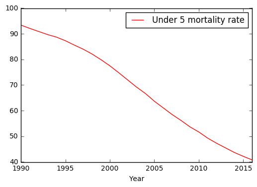

```python
%matplotlib inline
df_data_1.plot(x="Year",y="Under 5 mortality rate", color="Red")
```

# Under 5 mortality rates by country for 2016 (rates per thousand)

```python
body = client_c4c30ecfa40c4cbb923cfad6f1dd1055.get_object(Bucket='childmortalityrateunder5analysib0419166aaf146e5a4d747e61df6a5a9',Key='data-5.csv')['Body']
# add missing __iter__ method, so pandas accepts body as file-like object
if not hasattr(body, "__iter__"): body.__iter__ = types.MethodType( __iter__, body )

df_data_2 = pd.read_csv(body)
```

```python
df_data_2.head()
```

|  | Country | Year | Rate_per_th |
| --- | --- | --- | --- |
| 0 | Afghanistan | 2016 | 70.4 |
| 1 | Albania | 2016 | 13.5 |
| 2 | Algeria | 2016 | 25.2 |
| 3 | Andorra | 2016 | 2.7 |
| 4 | Angola | 2016 | 82.5 |

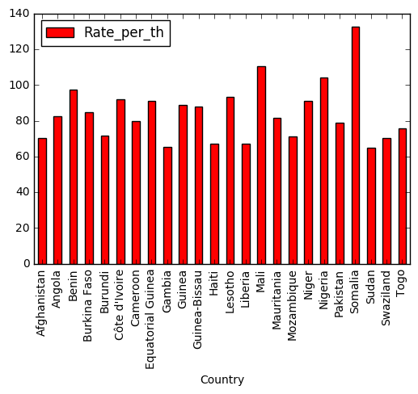

```python
%matplotlib inline

top_count=df_data_2.loc[df_data_2.Rate_per_th>=65,['Country','Rate_per_th']]

top_count.plot.bar(x="Country", y="Rate_per_th", color="Red")
```

# Data snapshot showing top causes for (under 5) deaths and countries affected

```python
body = client_c4c30ecfa40c4cbb923cfad6f1dd1055.get_object(Bucket='childmortalityrateunder5analysib0419166aaf146e5a4d747e61df6a5a9',Key='Causes.csv')['Body']
# add missing __iter__ method, so pandas accepts body as file-like object
if not hasattr(body, "__iter__"): body.__iter__ = types.MethodType( __iter__, body )

df_data_3 = pd.read_csv(body)
df_data_3.head()
```

|  | Data Value | Data Value.1 | Other | Congenital | Other.1 | Diarrhoea | Intrapartum | Injury | Pertussis | Malaria | Measles | Pneumonia | Meningitis | Preterm | Sepsis | Tetanus | AIDS |
| --- | --- | --- | --- | --- | --- | --- | --- | --- | --- | --- | --- | --- | --- | --- | --- | --- | --- |
| 0 | Area | Time Period | NaN | NaN | NaN | NaN | NaN | NaN | NaN | NaN | NaN | NaN | NaN | NaN | NaN | NaN | NaN |
| 1 | Kiribati | 2015 | NaN | 10.1 | 20.3 | 9.5 | 13.0 | 7.4 | 0.0 | 0.0 | 0.0 | 16.7 | 1.8 | 14.9 | 6.0 | 0.2 | 0.0 |
| 2 | Bangladesh | 2015 | NaN | 9.3 | 12.6 | 6.0 | 14.9 | 6.0 | 0.4 | 0.2 | 1.9 | 14.5 | 1.5 | 19.8 | 12.4 | 0.3 | 0.0 |
| 3 | Benin | 2015 | NaN | 5.1 | 16.8 | 10.8 | 9.4 | 5.7 | 1.0 | 11.6 | 0.7 | 15.4 | 2.4 | 12.9 | 7.0 | 0.2 | 1.1 |
| 4 | Bhutan | 2015 | NaN | 11.1 | 14.5 | 6.2 | 12.0 | 7.5 | 0.4 | 0.0 | 0.0 | 14.6 | 1.2 | 21.9 | 9.0 | 0.2 | 1.6 |

## 3 leading causes and countries most affected

### MALARIA

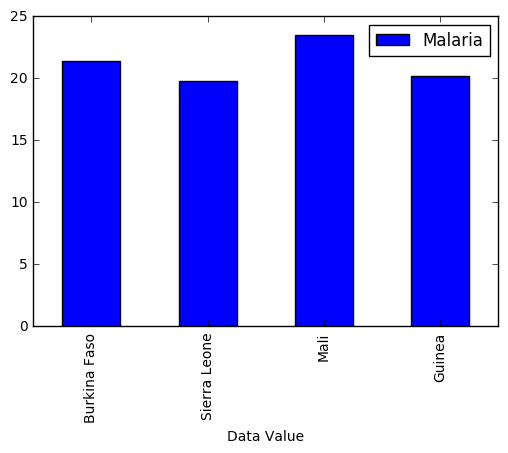

```python
malaria=df_data_3.loc[df_data_3.Malaria>=18,['Data Value','Malaria']]

malaria.plot.bar(x="Data Value", y="Malaria", color="Blue")
```

### PNEUMONIA

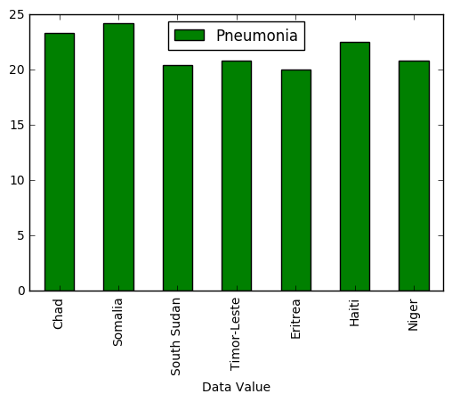

```python
pneumonia=df_data_3.loc[df_data_3.Pneumonia>=20,['Data Value','Pneumonia']]

pneumonia.plot.bar(x="Data Value", y="Pneumonia", color="Green")
```

### DIARRHOEA

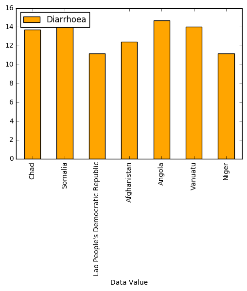

```python
diarrhoea=df_data_3.loc[df_data_3.Diarrhoea>=11,['Data Value','Diarrhoea']]

diarrhoea.plot.bar(x="Data Value", y="Diarrhoea", color="Orange")
```

### Conclusion: It is noted from the data above that in spite of a significant decline in under 5 mortality rates in the past 25 years, there remains a high incidence of under 5 mortality rates in a lot of under-developed countries. This is represented in the graphs for 3 significant mortality factors.